# stockyPuck Models for Zipline.io

December 10, 2015

## Agenda

- The Problem
- Methodology
- Details
- Findings

## Analysis of the problem.

- Investment Decisions
- Future Price Prediction
- Algorithmic Trading

## Methodology

- Fast Fourier Transform with Low Pass Filter
- Monte Carlo Simulation
- [Kelly Criterion](http://www.investopedia.com/articles/trading/04/091504.asp?layout=infini&v=2A)

## Methodology: Structure

1. Model the stock's true price
2. Compare with the market price
3. Make buy/sell/short decision based on the computed difference in step 2
   - in addition to current portfolio mix

## Methodology: Structure

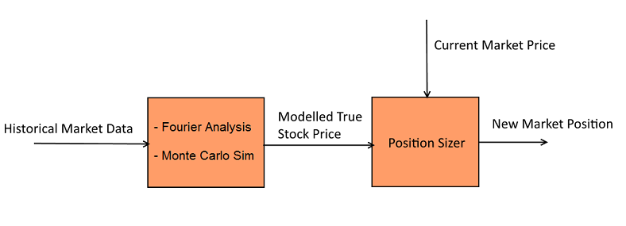

- Position Sizer: A variation on Kelly Criterion

## Details: Fast Fourier Transform

- Decomposition of a time series signal into the frequencies that it is comprised of
- Also known as the frequency domain representation of a signal
- Standard technique in the electrical engineering and signal processing worlds

\[ \begin{aligned} F \{ g(t)\} =G(f)=\int _{ -\infty }^{ \infty }{ { g(t) }e^{ -2\pi ift }dt } \end{aligned} \]

## Example Signal Transformation

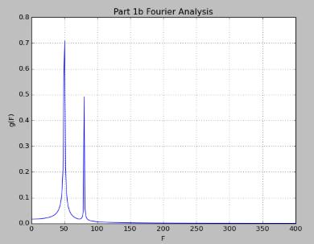

## Low Pass Filter

- Another signal processing technique
- Remove high frequency components of a signal
- Result will be a smoother signal
- Much easier to do in the frequency domain

## FFT Trading Thesis

- A stock chart is just a time series signal
- it looks noisy
- maybe if we filter out some of the high frequency noise we will be left with something closer to the stock's true price

## Example FFT Filtered Signal

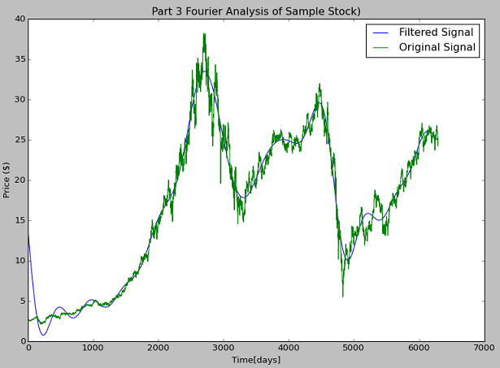

## Details: FFT Code

```python
  #get spectrum of signal with Fourier Transform using built in scipy method
  F = fft(s)

  #filter high frequency components of signals
  dt = 1/252.0
  f = fftfreq(len(F),dt)  # get sample frequency in samples per year

  F_filt = self.getfilteredsignal(F,f)
  F_filt = np.array(F_filt)

  # take inverse FFT to get smoothed time series signal
  s_filt = ifft(F_filt)
```

## Details: Low Pass Filter Code

```python
        if abs(freq)> (highCut+buff):
            return 0
        else:
            return x
```

- Easy!
- Time domain is more complex both conceptually and computationally \[ \begin{aligned} O({ n }^{ 2 })\quad for\quad Time\quad Domain \end{aligned} \] \[ \begin{aligned} O(nlogn)\quad for\quad Freq\quad Domain \end{aligned} \]

## Details: Monte Carlo Simulation

- Price Differences for past 10 days
- Mean Difference, Standard Deviation
- Random Sample from Normal distribution x 100
- Mean from Random Sample as Predicted Price

## Details: Monte Carlo Simulation

```python
priceDiffs = histData[sym].diff()
meanDiff = priceDiffs.mean()
sdDiff = priceDiffs.std()

mcResults = list()
for i in range(0, self.mcIterations, 1):
    res = self.monteCarloIteration(meanDiff, sdDiff, curPrice)
    mcResults.append(res)
# Convert to a pandas series so we can use the statistics functions.
mcResultsPd = pd.Series(mcResults)

# What is the price we predict for tomorrow?
predictedPrice = mcResultsPd.mean()
```

## Details: Monte Carlo Simulation

```python
def monteCarloIteration(self, mean, std, start):
    import random
    sample = list()
    for i in range(0, self.mcFutureDays, 1):
        sample.append(random.gauss(mean, std))

    curPrice = start
    walk = list()
    for d in sample:
        newPrice = curPrice + d
        curPrice = newPrice
        walk.append(curPrice)

    return walk[-1]
```

## Now What?

- We now have a price gap
- An Edge! (Maybe)
- What do we do with our edge?
- How many shares do we buy or sell?

## Kelly Criterion

- A way of maximizing growth by balancing a portfolio
- First made famous by mathematically inclined Blackjack players
- One of these players, Ed Thorp, first brought the technique to the market in the 1970s
- Rather complex with a porfolio of multiple stocks (Quadratic Programming Problem)
- Simplified considerably in our situation (1 stock + cash mix)

## Kelly Criterion

\[ \begin{aligned} { f }^{ * }\quad =\quad \frac { p(b+1)-1 }{ b } \end{aligned} \]

f*: fraction of portfolio to wager

p: probability of winning "bet"

b: net odds

## Findings

- Portfolio Starting Value: $100,000
- Back test: Jan 1, 2010 - Jan 1, 2014 (4 years)
- Variety of stocks and Index fund of S&P500

## Findings: Monte Carlo Simulation

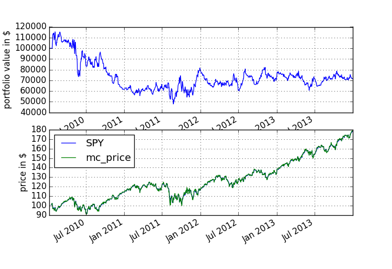

## Findings: Side by side

| Symbol | Company | FFT_EndPortfolioValue | MC_EndPortfolioValue |
| --- | --- | --- | --- |
| AAPL | Apple Inc. | 177,356.96 | 203,134.69 |
| MSFT | Microsoft | 60,084.11 | 60,276.67 |
| SPY | (Index) | 121,767.04 | 65,525.69 |
| GE | General Electric | 101,005.63 | 17,058.37 |
| GOOGL | Google | 237,267.42 | 22,173.25 |
| XOM | Exxon Mobil | 14,367.01 | 58,186.75 |
| YHOO | Yahoo | 219,306.11 | 151,692.87 |
| JNJ | Johnson and Johnson | 148,266.79 | 121,994.36 |
| KO | Coca Cola | 108,674.82 | 114,223.32 |
| GS | Goldman Sachs | 111,160.22 | 99,225.44 |

## Findings: Visually Side by side

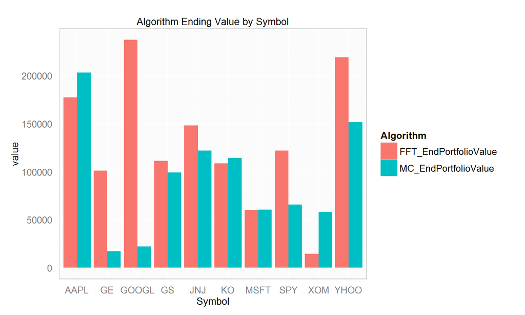

## Findings: Visually Side by side

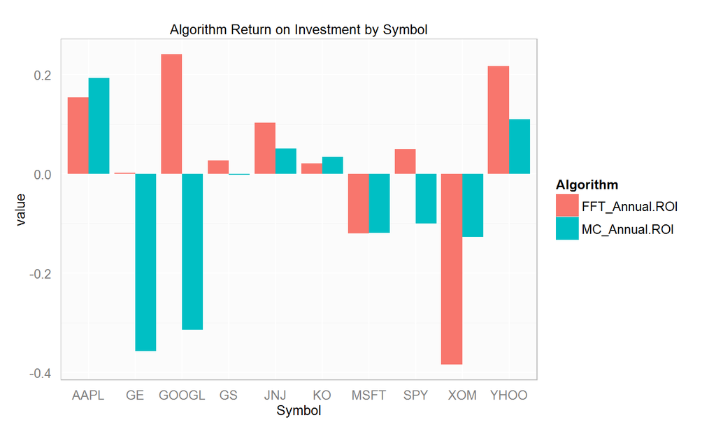

## Findings: Statistically

Raw Ending Value Statistics:

| Algorithm | median | mean | sd | n |
| --- | --- | --- | --- | --- |
| FFT_EndPortfolioValue | 116,463.63 | 129,925.61 | 68,341.92 | 10 |
| MC_EndPortfolioValue | 82,375.57 | 91,349.14 | 58,403.09 | 10 |

Return on Investment Statistics:

| Algorithm | median | mean | sd |
| --- | --- | --- | --- |
| FFT_Annual.ROI | 0.0386353 | 0.0312389 | 0.1812261 |
| MC_Annual.ROI | -0.0511157 | -0.0630453 | 0.1763825 |

## Hypothesis Test

\[H_0: \mu_{algo} = 100,000\]

\[H_a: \mu_{algo} > 100,000\]

\[\alpha = 0.05\]

## Hypothesis Test: FFT Normality Check

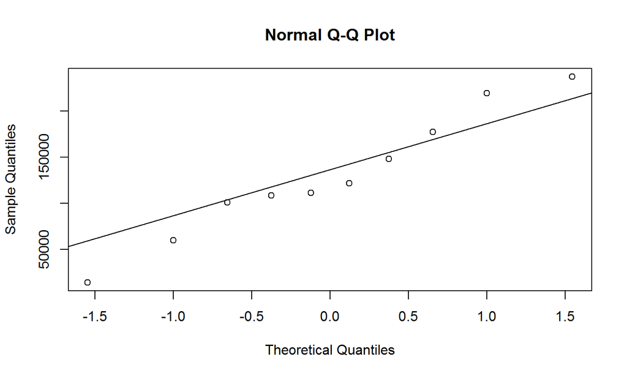

## Hypothesis Test: FFT Results

\[SE_{fft} = \frac{68,341.92}{\sqrt{10}} = 21,611.61\]

\[T_{fft} = \frac{129,925.6 - 100,000}{21,611.61} = 1.384701 \]

p-value = \(0.09975275 > 0.05\)

95% Confidence Interval: \(129,925.6 \pm 48,888.86 = \) \(81,036.75\) to \(178,814.5 \)

Based on the p-value \(\approx 0.0998\) and the 95%CI crossing the portfolio starting value, we accept the null hypothesis and conclude that the FFT model as written is not performing significantly better.

## Hypothesis Test: MC Normality Check

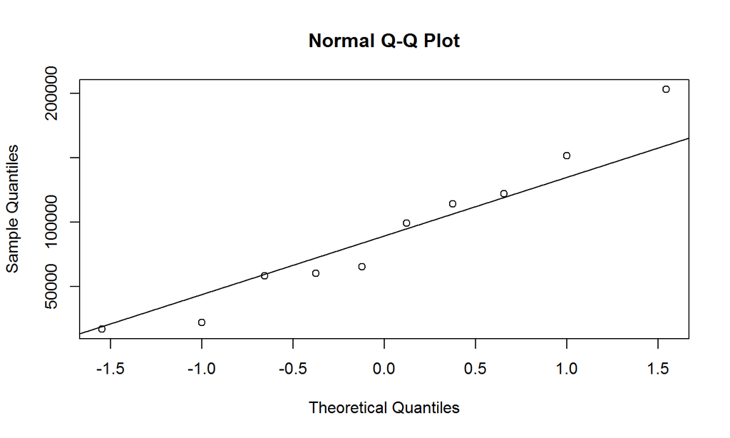

## Hypothesis Test: MC Results

\[SE_{fft} = \frac{58,403.09}{\sqrt{10}} = 18,468.68\]

\[T_{fft} = \frac{91,349.14 - 100,000}{18,468.68} = -0.4684071 \]

p-value = \(0.6746847 > 0.05\)

95% Confidence Interval: \(91,349.14 \pm 41,779.05 = \) \(49,570.09\) to \(133,128.2 \)

Based on the p-value \(\approx 0.6747\) and the 95%CI crossing the portfolio starting value, we accept the null hypothesis and conclude that the Monte Carlo model as written is not performing significantly better.

## Difference of Means Test

\[H_0: \mu_{fft} = \mu_{mc}\]

\[H_a: \mu_{fft} > \mu_{mc}\]

\[\alpha = 0.05\]

## Difference of Means Test

\[SE_{\bar{x}_{fft} - \bar{x}_{mc}} = \sqrt{\frac{68,341.92^2}{10} + \frac{58,403.09^2}{10} } = 28,428.05\]

\[T_{diff} = \frac{38,576.47 - 0}{28,428.05} = 1.356986 \]

p-value = \(0.1039196 > 0.05\)

Based on the p-value \(\approx 0.1039\) we do not reject the null hypothesis and therefore conclude that the Fast Fourier Transform is not significantly better than the Monte Carlo Simulation.

## Conclusions

- Tuning
- Improvement?
- Combination?

## Thank you

- Questions?